# Datenvisualisierung mit R

## Die erste Grafik

Dann sagen wir, was abgebildet werden soll…

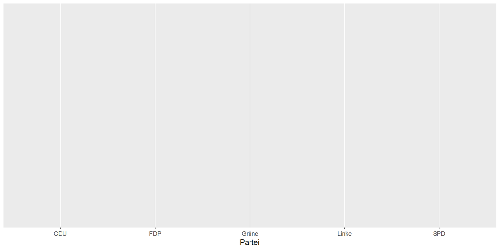

```r
ggplot(data = bt, aes(x = Partei))
```

… und welche Darstellungsart gewählt werden soll.

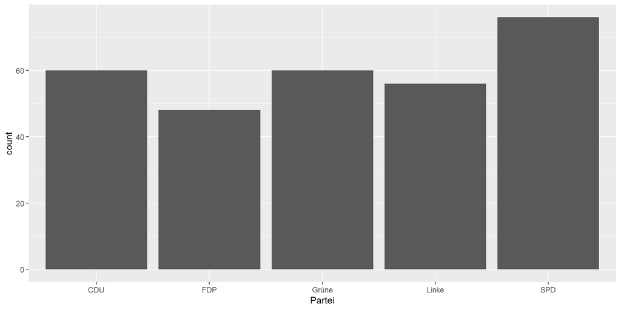

```r
ggplot(data = bt, aes(x = Partei))+
  geom_bar()
```

## Was wird durch `geom_bar()` dargestellt?

**Wichtig!**

Das `geom_bar()` ist darauf ausgerichtet, die Gruppengröße in **absoluten Zahlen** darzustellen. Es zählt, wie viele Mitglieder eine Gruppe hat (= Anzahl der Zeilen pro Partei). Das heißt, die zugrunde liegende mathematische Methode ist `count`, wie Sie sehen, falls Sie in die Konsole `?geom_bar` eingeben. Oft wollen aber nicht absolute, sondern relative Zahlen, also Prozentwerte. Dazu kommen wir noch.

## Die erste Grafik: Achsenbeschriftung

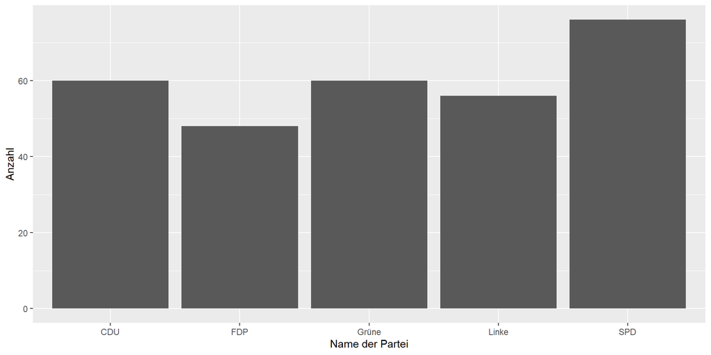

```r
ggplot(data = bt, aes(x = Partei))+
  geom_bar()+
  labs(y = "Anzahl", # der Zeilenumbruch ist nicht notwendig
       x = "Name der Partei")
```

## Die erste Grafik: Achsenbeschriftung

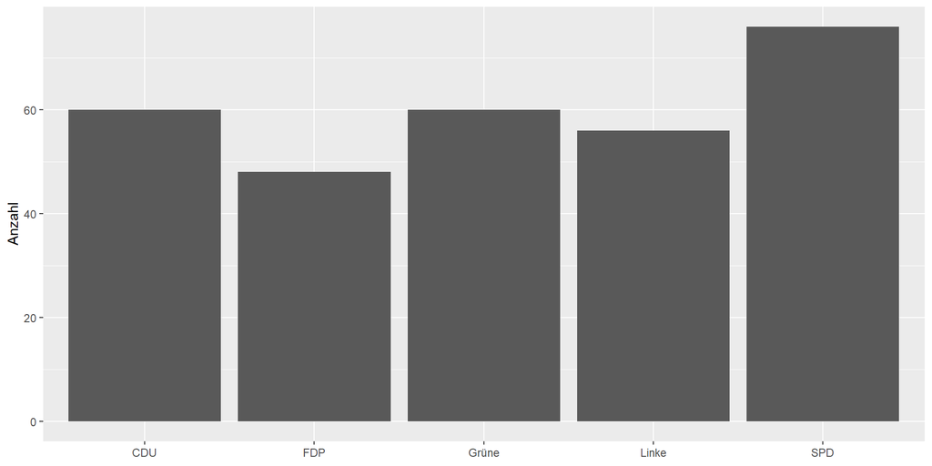

```r
ggplot(data = bt, aes(x = Partei))+
  geom_bar()+
  labs(y = "Anzahl",
       x = NULL)
```

## Die erste Grafik: Farben

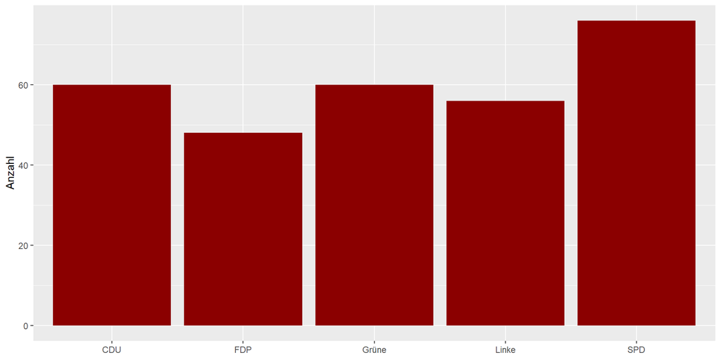

```r
ggplot(data = bt,
       mapping = aes(x = Partei))+
  geom_bar(fill = "darkred")+
  labs(y = "Anzahl",
       x = NULL)
```

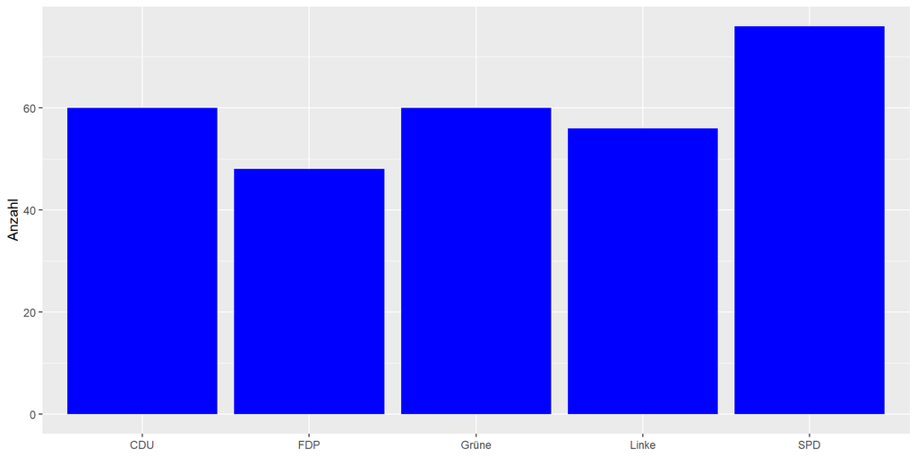

```r
ggplot(data = bt,
       mapping = aes(x = Partei))+
  geom_bar(fill = "blue")+
  labs(y = "Anzahl",
       x = NULL)
```

## Fill oder color?

Was passiert, wenn Sie in der Syntax `fill` durch `color` ersetzen?

Was passiert, wenn Sie `geom_bar(fill = "white", color = "red")` eingeben?

Was passiert, wenn Sie statt des Worts “blue” den HEX-Farbencode “#E95D00” eingeben?

## Echte Daten

Bitte laden Sie die Datei bt_fraktionen.xlsx aus dem Order “Datensätze” in Moodle herunter und speichern Sie diese in Ihrem Ordner “data”, der sich im Ordner “datavis” befinden sollte.

Wir nutzen das Package **[rio](https://www.rdocumentation.org/packages/rio/versions/1.2.3)**, um Daten mit dem Befehl `import()` einzulesen, weil es für fast alle Datenformate funktioniert. Fügen Sie das Package in den Code-Block ganz oben im Dokument ein (bei `p_load()`), führen Sie den Code-Block erneut aus und laden Sie dann die Daten unter dem Namen “fraktionen” in einem neuen Code-Block ganz unten im Dokument.

```r
p_load(here, rio, tidyverse) # oben ergänzen und den Code erneut ausführen.

fraktionen <- import(here("data", "bt_fraktionen.xlsx")) # relative Pfade!!
```

## Den Datensatz kennenlernen

Verwenden Sie nun die vergangene Woche eingeführten Befehle (`str()`, `glimpse()` und `view()`), um sich den Datensatz anzuschauen. Wie viele Spalten und Zeilen gibt es und welche Informationen enthalten diese?

## Anteil weiblicher Abgeordneter errechnen

Der Befehl, mit dem Sie den Mittelwert erhalten, lautet `mean()`. Errechnen Sie in der Konsole jeweils den Mittelwert der Spalten m und w.

Die Summe ermitteln Sie über `sum()`.

```r
all <- sum(fraktionen$m) + sum(fraktionen$w)
female <- sum(fraktionen$w)
perc_female <- female/all*100

round(perc_female,1)
```

```
[1] 35.1
```

## Anzahl weiblicher Abgeordneter darstellen

Erstellen Sie nun ein Balkendiagramm, bei dem die Parteien auf der x-Achse und die **Anzahl** weiblicher Abgeordneter auf der y-Achse abgetragen sind. Oben im Dokument finden Sie eine Vorlage.

## Anzahl weiblicher Abgeordneter

Warum klappt das nicht???

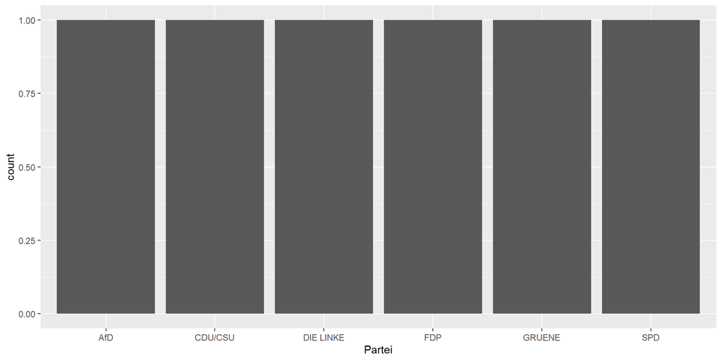

## geom_bar() vs. geom_col()

**Important**

Wenn Ihre Daten bereits zusammengefasst sind oder Werte für y (Höhe der Balken) enthalten, verwenden Sie `geom_col()`. Wenn Sie jedoch möchten, dass `ggplot()` die Anzahl der Zeilen pro Gruppe in Ihrem Datensatz zählt, verwenden Sie `geom_bar()`.

Geben Sie bitte den Befehl `?geom_col` in die Konsole ein.

Erstellen Sie nun die Grafik erneut und ersetzen Sie `geom_bar()` durch `geom_col()`. Welche Fehlermeldung erhalten Sie?

## Anzahl weiblicher Abgeordneter

`geom_bar()` bezieht sich auf eine Spalte – deshalb müssen wir nur `aes(x = ...)` eingeben.

Im Gegensatz dazu muss in `geom_col()` angegeben werden, welche Variable auf der x-Achse und welche auf der y-Achse dargestellt werden soll `aes(x = Partei, y = w)`:

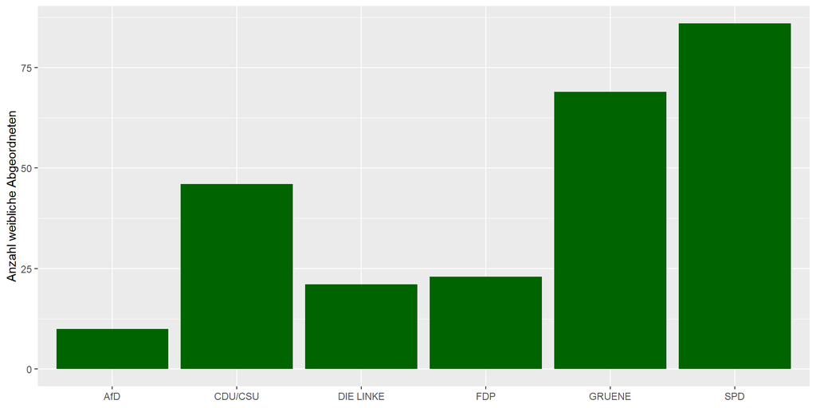

```r
ggplot(data = fraktionen, aes(x = Partei,
                              y = w))+
  geom_col(fill = "darkgreen")+
  labs(x = NULL,
       y = "Anzahl weibliche Abgeordneten")
```

## Aber wie stellen wir Frauen und Männer gleichzeitig dar?

In unserem Datensatz sind die Daten im **weiten Format** abgelegt. Das heißt, die Informationen zu weiblichen und mänlichen Abgeordneten befinden sich in **nebeneinander stehenden Spalten**. Mit `aes(x = Partei, y = w)` können wir **nicht** auf beide Spalten gleichzeitig zugreifen. Um auf die Anzahl weiblicher und männlicher Abgeordneter in `ggplot()` zugreifen zu können, müssen diese Informationen **in einer Spalte** vorhanden sein.

Der Datensatz *Fraktionen*

im weiten Format

| id | Partei | m | w |
| --- | --- | --- | --- |
| 1 | AfD | 68 | 10 |
| 2 | CDU/CSU | 150 | 46 |
| 3 | DIE LINKE | 18 | 21 |
| 4 | FDP | 69 | 23 |
| 5 | GRUENE | 47 | 69 |
| 6 | SPD | 120 | 86 |

## Wide and long format

Um unseren Datensatz in das lange Format zu bringen, müssen wir den Befehl `pivot_longer()` verwenden. Hierzu legen wir fest, welche Spalte wir beibehalten und welche Spalten nicht nebeneinander, sondern untereinander auftauchen sollen.

```r
fraktionen_long <- fraktionen %>% # wir speichern das Ergebnis unter neuem Namen
  pivot_longer(-c("Partei", "id"), names_to = "Geschlecht", values_to = "Anzahl")
```

Beachten Sie das Minuszeichen vor dem `-c`, weil die Spalten beibehalten und – in diesem Fall – verdoppelt werden sollen.

```r
view(fraktionen_long) # eher in der Konsole eingeben
```

## Wie hat sich der Datensatz verändert?

Der Datensatz *Fraktionen*

im langen Format

| id | Partei | Geschlecht | Anzahl |
| --- | --- | --- | --- |
| 1 | AfD | m | 68 |
| 1 | AfD | w | 10 |
| 2 | CDU/CSU | m | 150 |
| 2 | CDU/CSU | w | 46 |
| 3 | DIE LINKE | m | 18 |
| 3 | DIE LINKE | w | 21 |
| 4 | FDP | m | 69 |
| 4 | FDP | w | 23 |
| 5 | GRUENE | m | 47 |
| 5 | GRUENE | w | 69 |
| 6 | SPD | m | 120 |
| 6 | SPD | w | 86 |

## Die “Pipe” %>%

Unter der Hand habe ich ein wichtiges Zeichen eingeführt, ohne es zu erläutern. In `R` können wir Befehle **miteinander verketten**, indem wir das Symbol %>% verwenden. Die so genannte “Pipe” erlaubt es, viele Arbeitsschritte nacheinander auszuführen, ohne die Zwischenschritte abzuspeichern.

Sie fügen %>% über die Tastenkombination `strg + shift + m` ein.

**Tipp**

Nach `%>%` sollte immer ein Zeilenumbruch erfolgen, sodass der nächste Befehl zu Beginn der neuen Zeile steht – das macht den Code leichter lesbar.

## Ein Beispiel

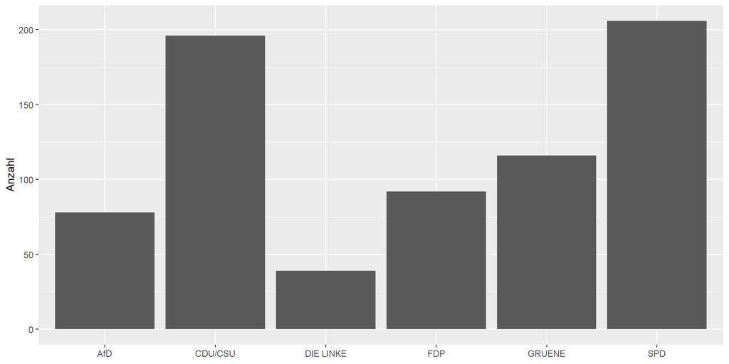

```r
# Datensatz auswählen
fraktionen %>%

  # neue Spalte ergänzen
  mutate(alle = m + w) %>%

  # Grafik erstellen
  # Vorsicht: ("data = fraktionen" fällt weg!)
  ggplot(aes(x = Partei, y = alle))+
  geom_col()+
  labs(x = NULL, y = "Anzahl")
```

## Neue Spalten/Variablen mit `mutate()` einfügen

Wie gerade gesehen haben, können wir mit `mutate()` neue Spalten im Datensatz erzeugen. Zunächst legen wir den Namen der neuen Spalte fest und geben dann an, was sie enthalten soll.

Verwenden Sie nun `%>%` und `mutate()`, um den **Anteil weiblicher Abgeordneter** in jeder Partei zu errechnen. Erstellen Sie ein Balkendiagramm, das die **Prozentwerte** auf der y-Achse abbildet.

## Balkendiagramm mit Prozentwerten

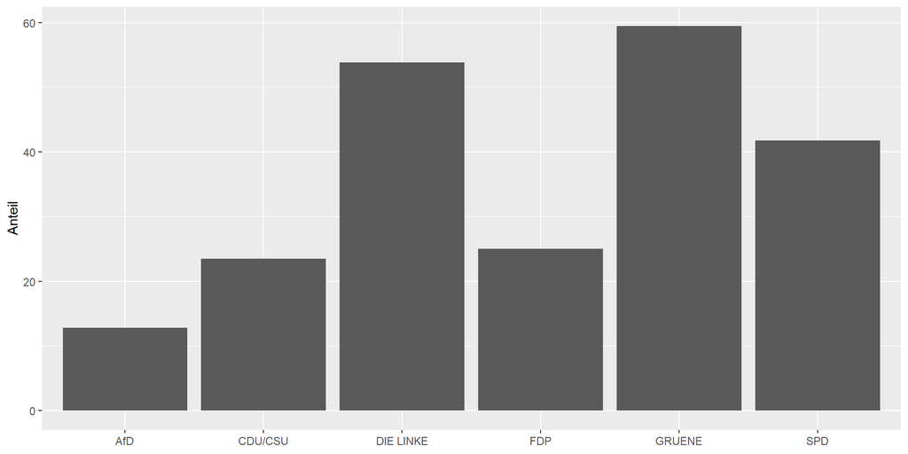

```r
fraktionen %>%
  mutate(alle = m + w, anteil_w = w/alle*100) %>% # Prozentwerte erstellen
  ggplot(aes(x = Partei, y = anteil_w))+
  geom_col()+
  labs(x = NULL, y = "Anteil")
```

## Geordnetes Balkendiagramm mit Prozentwerten

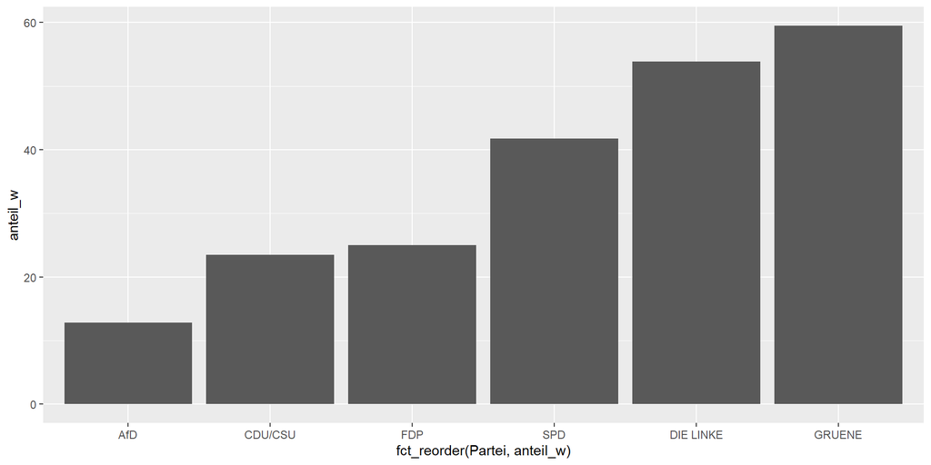

```r
fraktionen %>% # wählt Datensatz aus
  mutate(alle = m + w, anteil_w = w/alle*100) %>% # generiert neue Variablen
  ggplot(aes(x = fct_reorder(Partei, anteil_w), # ordnet die Variable "Partei"
             y = anteil_w)) +
  geom_col()
```

## Alternative Vorgehensweise

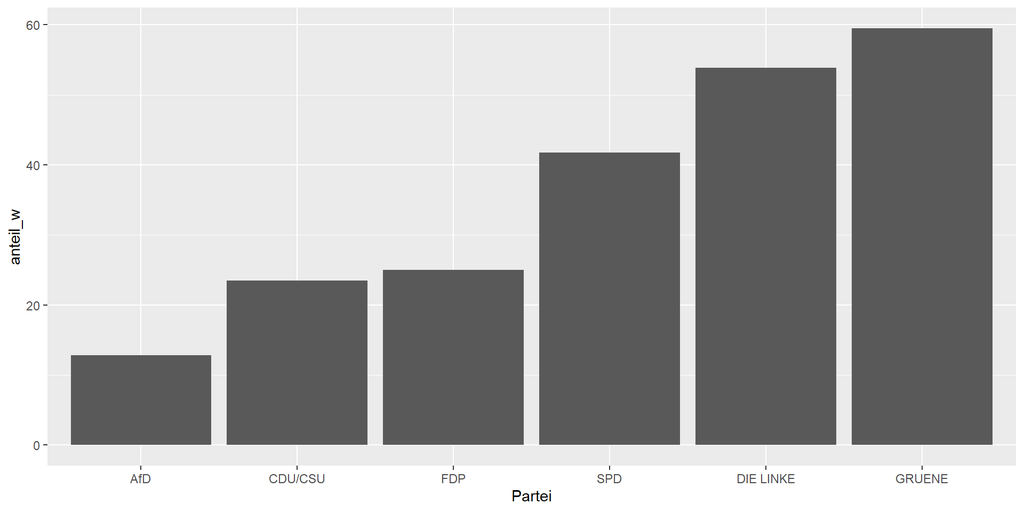

```r
fraktionen %>% # wählt Datensatz aus
  mutate(alle = m + w, anteil_w = w/alle*100) %>% # generiert neue Variablen
  mutate(Partei = fct_reorder(Partei, anteil_w)) %>% # ordnet den Datensatz
  ggplot(aes(x = Partei, y = anteil_w)) + # erstellt die Grafik
  geom_col() # legt die Darstellungsart fest
```

## Alternative Vorgehensweise

wie eben:

```r
fraktionen %>%
  mutate(alle = m + w, anteil_w = w/alle*100) %>%
  mutate(Partei = fct_reorder(Partei, anteil_w)) %>%
  ggplot(aes(x = Partei, y = anteil_w)) +
  geom_col()
```

neu:

```r
fraktionen %>%
  mutate(
    alle = m + w, anteil_w = w/alle*100,
    Partei = fct_reorder(Partei, anteil_w)) %>% # mehrere Umwandlungen innerhalb von mutate()
  ggplot(aes(x = Partei, y = anteil_w)) +
  geom_col()
```

## Balken unterteilen

Wir verwenden nun wieder den vorhin erstellten Datensatz fraktionen_long. Wie schaffen wir es, nicht nur die Gesamtzahl der Abgeordneten pro Partei darzustellen, sondern auch noch weibliche und männliche Abgeordnete farblich voneinander abzusetzen?

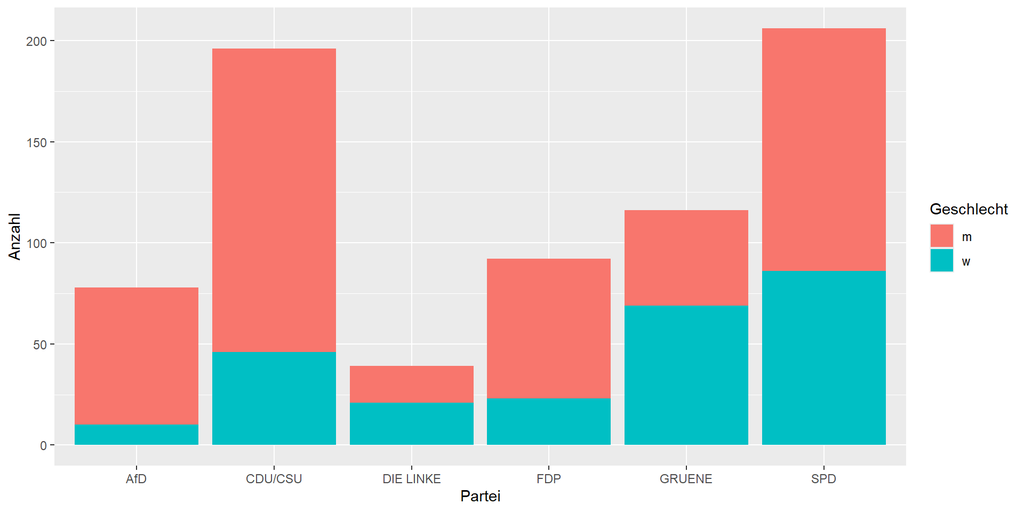

## Die Farbe über eine Variable bestimmen

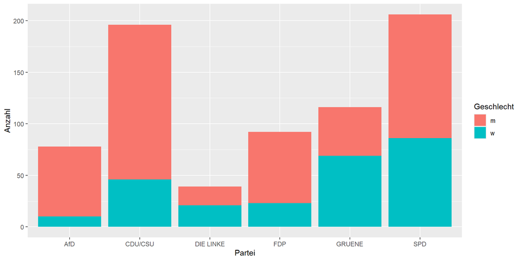

```r
ggplot(data = fraktionen_long,
       aes(x = Partei, y = Anzahl, fill = Geschlecht))+
  geom_col()
```

Wie unterscheidet sich der Code von der Farbverwendung weiter oben?

## Die Farbe über eine Variable bestimmen

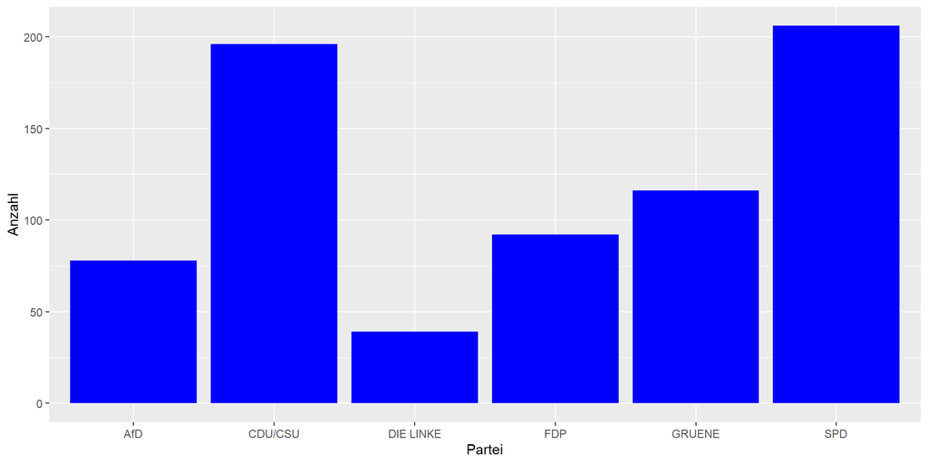

```r
ggplot(data = fraktionen_long,
       aes(x = Partei, y = Anzahl,
           fill = Geschlecht))+ # Farbe ist Teil von aes(...)
  geom_col(fill = "blue") # überschreibt den Befehl aus der Zeile zuvor
```

## Balken übereinander oder nebeneinander?

Um dies festzulegen – voreingestellt ist das gestapelte Balkendiagramm – müssen wir in der Zeile `geom_col()` Informationen zur Position einfügen. Recherchieren Sie online, wie das gehen könnte.

Welche anderen Darstellungsarten können über die Position noch bestimmt werden?

## Balken nebeneinander

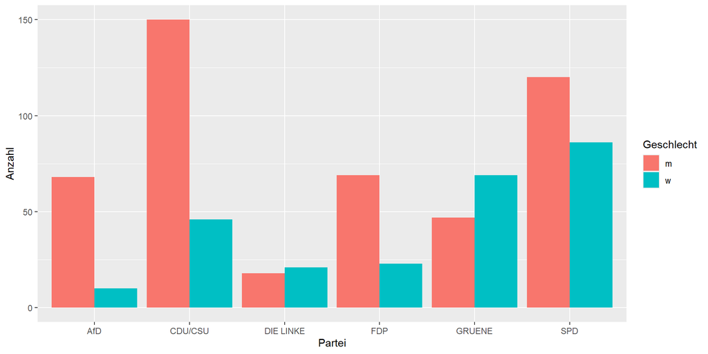

```r
ggplot(data = fraktionen_long,
       aes(x = Partei, y = Anzahl, fill = Geschlecht))+
  geom_col(position = "dodge")
```

## Anteile automatisch darstellen

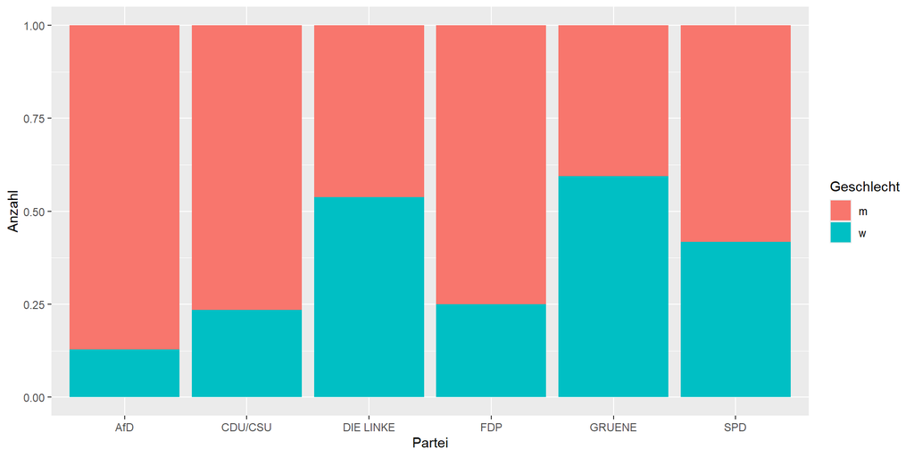

```r
ggplot(data = fraktionen_long,
       aes(x = Partei, y = Anzahl, fill = Geschlecht))+
  geom_col(position = "fill")
```

## Scales – um die Farben zu ändern

“Scales in ggplot2 control the *mapping from data to aesthetics*. They take your data and turn it into something that you can see, like size, colour, position or shape. They also provide the tools that let you interpret the plot: the axes and legends. You can generate plots with ggplot2 without knowing how scales work, but understanding scales and learning how to manipulate them will give you much more control.”

Hadley Wickham in ggplot2-book.org

## Scales – um die Farben zu ändern

Diese Skalen sind eine weitere Schicht, die einem `ggplot()` hinzugefügt werden können. Die Befehle fangen immer mit `scale_` an, denn kommt, worauf sich die Skala bezieht, und dann, wie sie geändert werden soll. Beispiele:

`scale_color_manual(values = c("red", "blue")`

`scale_fill_manual(values = c("red", "blue"))`

`scale_alpha_manual(values = c(0.8, 0.2))`

Fügen Sie die zweite Zeile dem Code hinzu.

## Scales verwenden

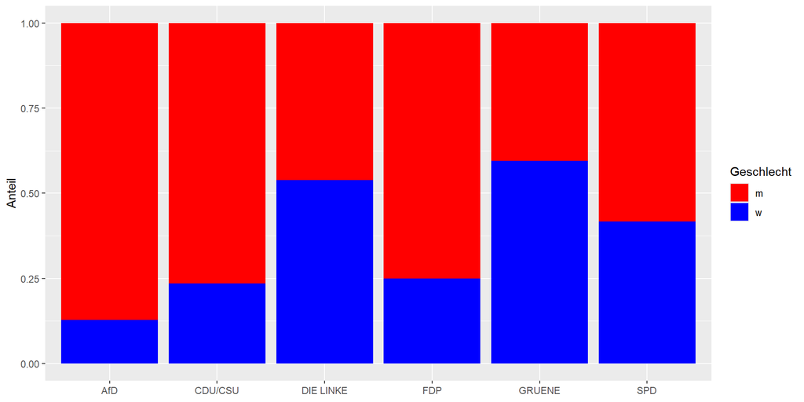

```r
ggplot(data = fraktionen_long,
       aes(x = Partei, y = Anzahl, fill = Geschlecht))+ # legt die Variable fest
  geom_col(position = "fill")+
  scale_fill_manual(values = c("red", "blue"))+ # bestimmt die Farben
  labs(x = NULL, y = "Anteil")
```

## Scales verwenden – was hat sich verändert?

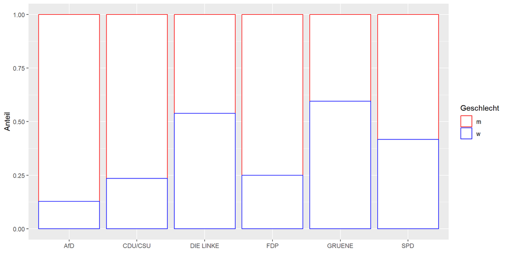

```r
ggplot(data = fraktionen_long,
       aes(x = Partei, y = Anzahl, color = Geschlecht))+
  geom_col(fill = "white", position = "fill")+
  scale_color_manual(values = c("red", "blue"))+
  labs(x = NULL, y = "Anteil")
```

## Scales verwenden

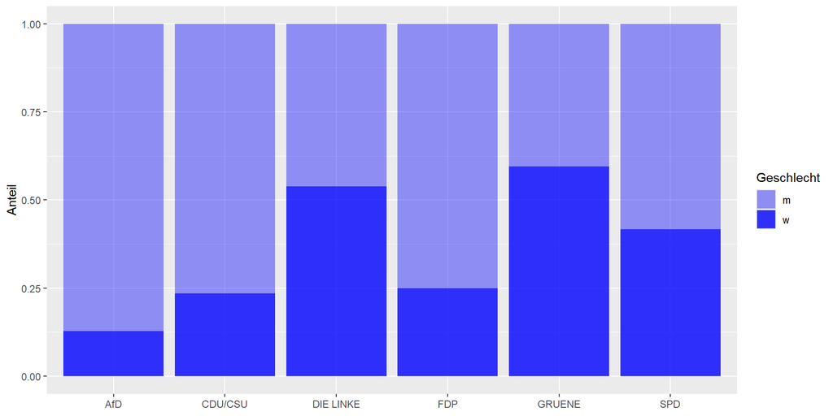

```r
ggplot(data = fraktionen_long,
       aes(x = Partei, y = Anzahl, alpha = Geschlecht))+
  geom_col(position = "fill", fill = "blue")+
  scale_alpha_manual(values = c(0.4, 0.8))+ # der Transparenzgrad liegt zw. 0 und 1.
  labs(x = NULL, y = "Anteil")
```

## Übungsaufgabe (für zu Hause)

Erstellen Sie möglichst exakt die auf der folgenden Seite stehende Abbildung, aber verwenden Sie den Datensatz **fraktionen**. Verwenden Sie die `%>%`, erstellen Sie neue Variablen, wählen Sie die benötigten Spalten mit (`select`) aus, bringen Sie den Datensatz ins lange Format und erstellen Sie dann die Grafik.

Vorsicht: Um die Grafik exakt reproduzieren zu können, müssen Sie Tricks recherchieren, die wir noch nicht besprochen haben! Alle Hilfsmittel sind erlaubt.<sup>1</sup>

[^1]: Für die Farben können Sie [hier](https://waldyrious.net/viridis-palette-generator/) nachschauen.

## Übungsaufgabe (für zu Hause)

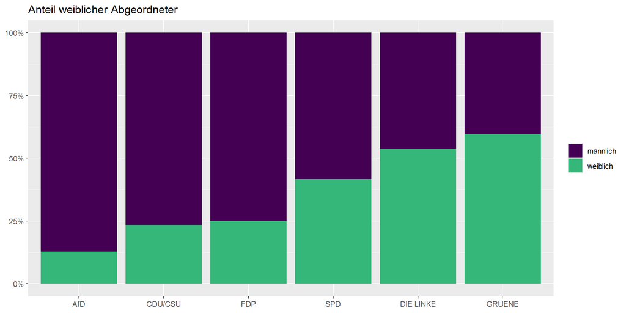

[figure not shown]

Datenvisualisierung